# Whack-a-Mole Eye Tracking Analysis

Bastian Ilsø Hougaard, Hendrik Knoche

3/27/2020

## Table of Contents

1. Introduction
2. Oculometrics

## Introduction

This document provides analysis of data collected by Whack-A-Mole VR and Pupil Capture:

- `gameLog.csv` is Whack-A-Mole’s game data.
- `export_info.csv` is generic export information from Pupil Capture.
- `fixation_report.csv` is Pupil Player’s aggregated summary of counted fixations.
- `fixations.csv` contains every fixation found during the game.
- `pupil_positions.csv` contains every frame of data from the eye tracking cameras.
- `gaze_positions.csv` contains Pupil’s interpreted 3D gaze data (how it maps to VR).
- `world_timestamps.csv` contains mapping from pupil_time to frame in the recorded video.
- `world.mp4` is the annotated video.

## Oculometrics

### TODO

- Calculate things with `PupilSize` - maybe for Pupil Dilation..
- Saccade analysis (?)

### Summarizing Eye movements as visual angles.

In eye tracking analysis we prefer to analyze data using established units such as visual angles.

#### Using PFA’s suggestion

The below results is the based on using PFA’s calculation method. His calculation method assumes that the origin position of the eye is `0,0,0`. Therefore distance is simply assumed to be the vectors’ magnitude.

**Math:** `angle = arccos( (a dot b) / (|a| * |b|) )`

| min | quantile1 | mean | quantile3 | max |
| --- | --- | --- | --- | --- |
| 0 | 0.08 | 22 | 5.8 | 180 |

| point_a | point_b | angle |
| --- | --- | --- |
| 9.56, -169.11, 990.07 | 9.23, -172.34, 998.5 | 0.1 |

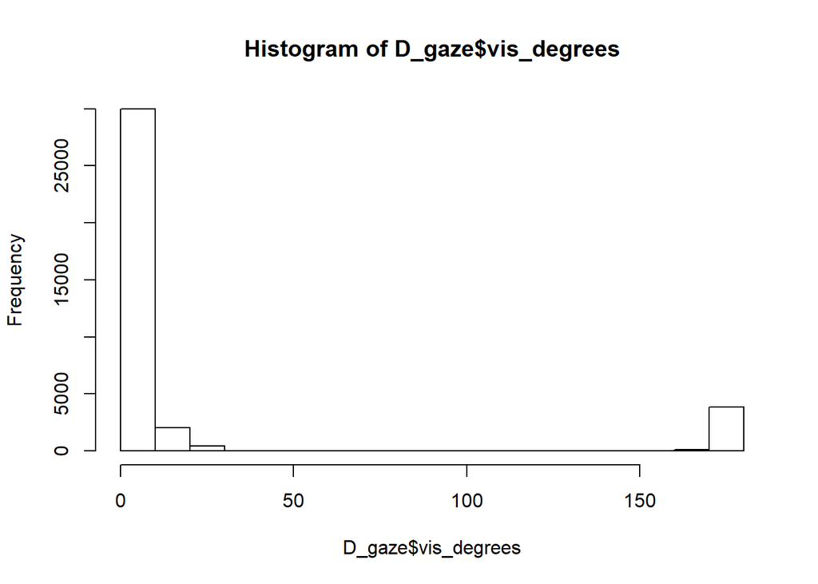

#### Using Stephen Rhode’s Implementation

Stephen Rhode’s implementation uses `size` and `distance` to calculate visual angle. In this case, we determine `size` as magnitude of gaze position `gaze_point_3d` from previous gaze position, and `distance` as magnitude of gaze position from eye position `eye_center0_3d`.

**Math:** `angle = 2*arctan( size / (2 * distance) )`

| eye1_min | eye1_quantile1 | eye1_mean | eye1_quantile3 | eye1_max |
| --- | --- | --- | --- | --- |
| 0 | 2 | 19 | 16 | 180 |

| eye2_min | eye2_quantile1 | eye2_mean | eye2_quantile3 | eye2_max |
| --- | --- | --- | --- | --- |
| 0 | 1.9 | 19 | 15 | 180 |

| point_a | point_b | eye1 | size | distance | angle |
| --- | --- | --- | --- | --- | --- |
| 9.56, -169.11, 990.07 | 9.23, -172.34, 998.5 | 33.5, 0.1, 0.32 | 9 | 1013 | 0.51 |

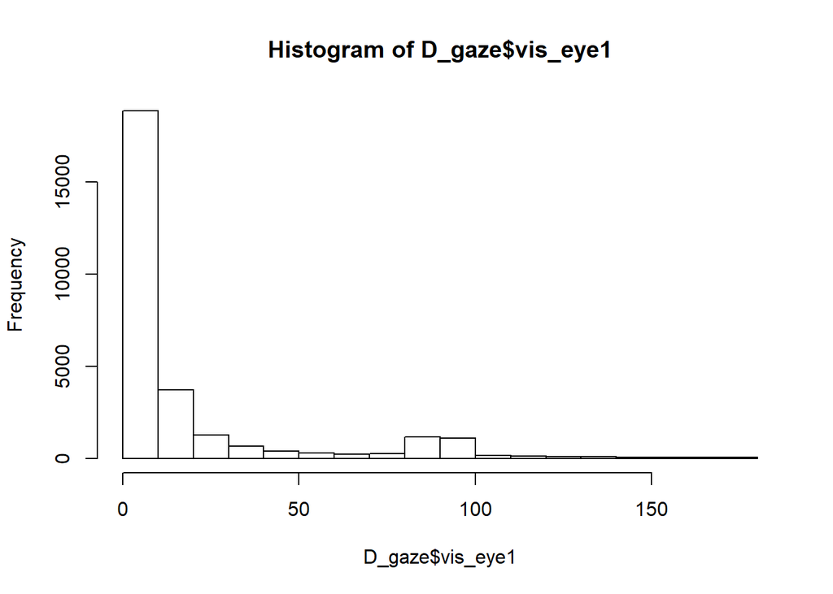

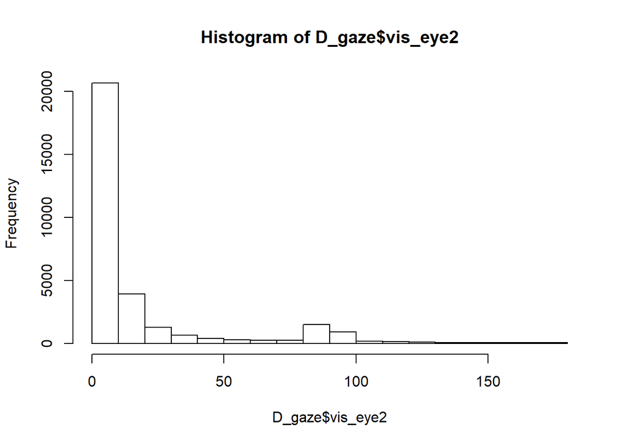